# Ch05 5_1 Validation Set

Bruce Hartman

University of St. Francis

2025-08-18 Revised 2026-10-17T09:10:30

Abstract

# Introduction

This paper is based on the text Section 5.1.1, using the Auto dataset, from the `ISLR2` package.

# Packages

First we load the relevant packages to our notebook session.

```r
library(glmnet) # for ridge and lasso
library(ISLR2) #package contains the data files, but not this one
library(mbadtools, quietly=TRUE) # used to manipulate data and plot
```

# Data

The data come from the `ISLR2` package.

```r
data(Auto, package="ISLR2")
Auto %>% skim
```

```
── Data Summary ────────────────────────
                           Values
Name                       Piped data
Number of rows             392
Number of columns          9
_______________________
Column type frequency:
  factor                   1
  numeric                  8
________________________
Group variables            None
```

|  | skim_variable | n_missing | complete_rate | ordered | n_unique | top_counts |
| --- | --- | --- | --- | --- | --- | --- |
| 1 | name | 0 | 1 | FALSE | 301 | amc: 5, for: 5, toy: 5, amc: 4 |

|  | skim_variable | n_missing | complete_rate | mean | sd | p0 | p25 | p50 | p75 | p100 | hist |
| --- | --- | --- | --- | --- | --- | --- | --- | --- | --- | --- | --- |
| 1 | mpg | 0 | 1 | 23.445918 | 7.8050075 | 9 | 17.000 | 22.75 | 29.000 | 46.6 | ▆▇▆▃▁ |
| 2 | cylinders | 0 | 1 | 5.471939 | 1.7057832 | 3 | 4.000 | 4.00 | 8.000 | 8.0 | ▇▁▃▁▅ |
| 3 | displacement | 0 | 1 | 194.411990 | 104.6440039 | 68 | 105.000 | 151.00 | 275.750 | 455.0 | ▇▂▂▃▁ |
| 4 | horsepower | 0 | 1 | 104.469388 | 38.4911599 | 46 | 75.000 | 93.50 | 126.000 | 230.0 | ▆▇▃▁▁ |
| 5 | weight | 0 | 1 | 2977.584184 | 849.4025600 | 1613 | 2225.250 | 2803.50 | 3614.750 | 5140.0 | ▇▇▅▅▂ |
| 6 | acceleration | 0 | 1 | 15.541327 | 2.7588641 | 8 | 13.775 | 15.50 | 17.025 | 24.8 | ▁▆▇▂▁ |
| 7 | year | 0 | 1 | 75.979592 | 3.6837365 | 70 | 73.000 | 76.00 | 79.000 | 82.0 | ▇▆▇▆▇ |
| 8 | origin | 0 | 1 | 1.576531 | 0.8055182 | 1 | 1.000 | 1.00 | 2.000 | 3.0 | ▇▁▂▁▂ |

# Data Wrangling

The column `name` has a lot of discrete values and is not very good for regression or other analyses.

# Research Problem

We’ll try to fit a *polynomial model* to predict mpg (the target) from polynomial functions of horsepower, the driver variable. We want to understand how crossvalidation works in this simple example, and uncover some of the pitfalls. We first plot `mpg` vs `horsepower` to guess at the polynomial relation.

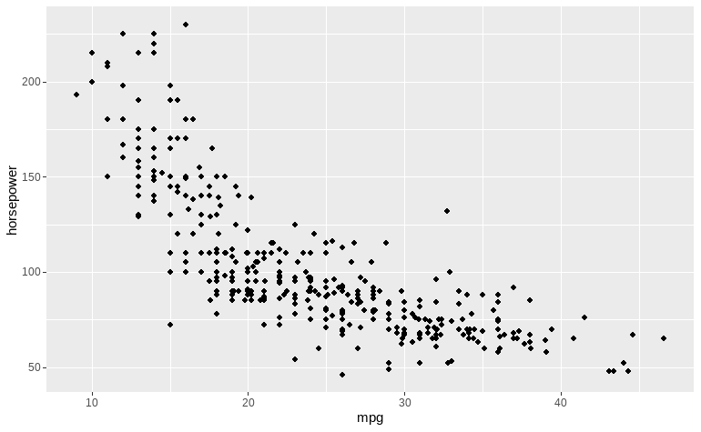

```r
ggplot(Auto, aes(mpg, horsepower)) +
  geom_point()
```

It’s a curve, so a square (k=2 in the `poly` function) should be a good fit.

In particular, we want to reproduce Figure 5.2 in the text. It shows the results of the validation set approach. The left panel graphs Mean Squared Error (MSE) as a function of the order of the polynomial used for the model, for a single split, or partition of the data into training and test datasets. The right graph shows MSE computed in 10 separate splits of the data.

We can compute RMSE using the `yardstick::rmse_vec()` function. Squaring it gives MSE. `yardstick` package is included in `mbadtools`.

# Training and Test data

We first divide the dataset into training and test portions. The `sample()` function randomly picks row numbers from the total number of rows of the dataset. Then we select the rows using the `train` vector and the `-train` vector for the test data. To make results reproducible we set the seed of the random number generator to 1. We select half the data for training, leaving half for test.

```r
set.seed(1)
train=sample(nrow(Auto), nrow(Auto)/2, replace=FALSE)
train.auto=Auto[train,]
test.auto=Auto[-train,]

train.auto %>% gt %>% opt_interactive
```

| mpg | cylinders | displacement | horsepower | weight | acceleration | year | origin | name |
| --- | --- | --- | --- | --- | --- | --- | --- | --- |
| 38.1 | 4 | 89 | 60 | 1968 | 18.8 | 80 | 3 | toyota corolla tercel |
| 38 | 4 | 105 | 63 | 2125 | 14.7 | 82 | 1 | plymouth horizon miser |
| 15 | 8 | 383 | 170 | 3563 | 10 | 70 | 1 | dodge challenger se |
| 29.9 | 4 | 98 | 65 | 2380 | 20.7 | 81 | 1 | ford escort 2h |
| 44.3 | 4 | 90 | 48 | 2085 | 21.7 | 80 | 2 | vw rabbit c (diesel) |
| 20 | 4 | 130 | 102 | 3150 | 15.7 | 76 | 2 | volvo 245 |
| 27.5 | 4 | 134 | 95 | 2560 | 14.2 | 78 | 3 | toyota corona |
| 33 | 4 | 105 | 74 | 2190 | 14.2 | 81 | 2 | volkswagen jetta |
| 17 | 6 | 250 | 100 | 3329 | 15.5 | 71 | 1 | chevrolet chevelle malibu |
| 27.2 | 4 | 135 | 84 | 2490 | 15.7 | 81 | 1 | plymouth reliant |

[output cut: 186 more lines]

```r
test.auto %>% gt %>% opt_interactive
```

| mpg | cylinders | displacement | horsepower | weight | acceleration | year | origin | name |
| --- | --- | --- | --- | --- | --- | --- | --- | --- |
| 18 | 8 | 318 | 150 | 3436 | 11 | 70 | 1 | plymouth satellite |
| 17 | 8 | 302 | 140 | 3449 | 10.5 | 70 | 1 | ford torino |
| 15 | 8 | 429 | 198 | 4341 | 10 | 70 | 1 | ford galaxie 500 |
| 14 | 8 | 454 | 220 | 4354 | 9 | 70 | 1 | chevrolet impala |
| 14 | 8 | 440 | 215 | 4312 | 8.5 | 70 | 1 | plymouth fury iii |
| 14 | 8 | 455 | 225 | 3086 | 10 | 70 | 1 | buick estate wagon (sw) |
| 24 | 4 | 113 | 95 | 2372 | 15 | 70 | 3 | toyota corona mark ii |
| 22 | 6 | 198 | 95 | 2833 | 15.5 | 70 | 1 | plymouth duster |
| 25 | 4 | 104 | 95 | 2375 | 17.5 | 70 | 2 | saab 99e |
| 26 | 4 | 121 | 113 | 2234 | 12.5 | 70 | 2 | bmw 2002 |

[output cut: 186 more lines]

# Linear Model

Next we fit the linear model `mpg`~`poly(horsepower,k)` on the training dataset. Start with k=1, a true linear model.

```r
lm.fit1=lm(mpg~poly(horsepower),data=train.auto)
lm.fit1 %>% glance() %>% gt_add_significance()
```

| r.squared | adj.r.squared | sigma | statistic | p.value | df | logLik | AIC | BIC | deviance | df.residual | nobs |
| --- | --- | --- | --- | --- | --- | --- | --- | --- | --- | --- | --- |
| 0.6141 | 0.6121 | 4.9337 | 308.6599 | 0.0000 | 1.0000 | −589.9401 | 1,185.8801 | 1,195.7145 | 4,722.2193 | 194.0000 | 196.0000 |

```r
lm.fit1 %>% tidy(conf.int=TRUE) %>% gt_add_significance()
```

| term | estimate | std.error | statistic | p.value | conf.low | conf.high |
| --- | --- | --- | --- | --- | --- | --- |
| (Intercept) | 23.3153 | 0.3524 | 66.1602 | 0.0000 | 22.6203 | 24.0103 |
| poly(horsepower) | −86.6787 | 4.9337 | −17.5687 | 0.0000 | −96.4093 | −76.9481 |

```r
rmse1 = rmse_vec(train.auto$mpg, lm.fit1$fitted.values)
rmse1
```

```
[1] 4.908458
```

Next we calculate it on the test data. It is the difference between the observed values and predicted values of `mpg` for the proper fit and test data sets.

```r
RMSE1 = rmse_vec(test.auto$mpg, predict(lm.fit1,test.auto))
RMSE1
```

```
[1] 4.88369
```

Next we try all polynomials of horsepower from 1 to 10. We want to see the best fit in terms of RMSE on the test data. We set up a vector `RMSE` to hold the 10 results. Then display the vector of RMSEs for the different predictions on the test data set. Because of the set.seed(1) we should get the same answer every time.

```r
RMSE=c()
for (i in 1:10) {
  f = lm(mpg~poly(horsepower,i), data=train.auto)
  RMSE[i] = rmse_vec( predict(f,test.auto), test.auto$mpg )
}
RMSE0 = RMSE %>% enframe(name="poly_deg", value="rmse")
RMSE0
```

| poly_deg | rmse |
| --- | --- |
| 1 | 4.883690 |
| 2 | 4.303150 |
| 3 | 4.308216 |
| 4 | 4.310874 |
| 5 | 4.238947 |
| 6 | 4.218635 |
| 7 | 4.203363 |
| 8 | 4.229810 |
| 9 | 4.271372 |
| 10 | 4.270336 |

# Figure 5.2 Left Graph

We use `ggplot` to construct this graph.

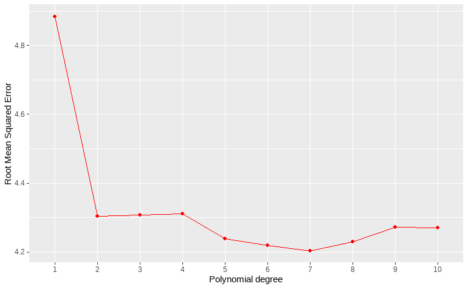

```r
ggplot(RMSE0) +
  geom_line(aes(poly_deg, rmse), color="red") +
  geom_point(aes(poly_deg, rmse), color="red") +
  coord_cartesian(xlim=c(1,10))+
  scale_x_discrete(limits=factor(1:10)) +
  labs(x = "Polynomial degree", y ="Root Mean Squared Error")
```

The graph shows that k=2, a quadratic polynomial, gives a good and simple result on the test data.

# Figure 5.2 Right Graph

Here we plot the results of the 10 CV repetitions for each polynomial degree from 1 to 10.

For the right graph we need to repeat the for loop above inside another for loop, setting a different seed each time. `RMSE3` is now a matrix of values with rows the different seeds (10 CV tries), and columns the `rmse` for different polynomials (10 of them).

```r
RMSE3=matrix(nrow=10, ncol=10)
for (k in 1:10) {
  set.seed(k+20)
  tr = sample(nrow(Auto),nrow(Auto)/2, replace=FALSE)
  train.df = Auto[tr,]
  test.df =  Auto[-tr,]

  # calculate the MSE values
  for (i in 1:10) {
    f = lm(mpg~poly(horsepower,i), data=train.df)
    RMSE3[k,i] = rmse_vec(test.df$mpg, predict(f,test.df))
  }
}
```

To get scale right, we have to find the largest number in RMSE3 and which row (k) it is in. We will plot that row first. Or maybe not if it is one outlier.

```r
w = which(RMSE3==max(RMSE3), arr.ind=TRUE)
w
```

```
     row col
[1,]  10  10
```

```r
RMSE3[w[1],w[2]]
```

```
[1] 6.353725
```

```r
summary(RMSE3)
```

```
       V1              V2              V3              V4              V5
 Min.   :4.597   Min.   :4.106   Min.   :4.114   Min.   :4.110   Min.   :4.046
 1st Qu.:4.717   1st Qu.:4.202   1st Qu.:4.201   1st Qu.:4.226   1st Qu.:4.180
 Median :4.962   Median :4.452   Median :4.460   Median :4.475   Median :4.485
 Mean   :4.929   Mean   :4.404   Mean   :4.421   Mean   :4.441   Mean   :4.391
 3rd Qu.:5.070   3rd Qu.:4.590   3rd Qu.:4.591   3rd Qu.:4.612   3rd Qu.:4.533
 Max.   :5.258   Max.   :4.611   Max.   :4.747   Max.   :4.766   Max.   :4.679
       V6              V7              V8              V9             V10
 Min.   :4.018   Min.   :3.986   Min.   :4.052   Min.   :4.012   Min.   :4.026
 1st Qu.:4.176   1st Qu.:4.157   1st Qu.:4.186   1st Qu.:4.199   1st Qu.:4.372
 Median :4.511   Median :4.492   Median :4.511   Median :4.527   Median :4.619
 Mean   :4.402   Mean   :4.432   Mean   :4.499   Mean   :4.565   Mean   :4.710
 3rd Qu.:4.566   3rd Qu.:4.571   3rd Qu.:4.595   3rd Qu.:4.726   3rd Qu.:4.753
 Max.   :4.660   Max.   :5.078   Max.   :5.507   Max.   :5.702   Max.   :6.354
```

# Use ggplot

| poly_deg | fold | rmse |
| --- | --- | --- |
| 1 | rmse.1 | 5.258223 |
| 1 | rmse.2 | 5.250515 |
| 1 | rmse.3 | 4.918069 |
| 1 | rmse.4 | 4.696841 |
| 1 | rmse.5 | 5.030358 |
| 1 | rmse.6 | 4.708826 |
| 1 | rmse.7 | 5.005719 |
| 1 | rmse.8 | 4.596932 |
| 1 | rmse.9 | 4.741711 |
| 1 | rmse.10 | 5.083023 |

[output cut: 90 more lines]

Instead of the figure, I like the boxplot, which shows medians and IQRs of the fold values of `rmse`.

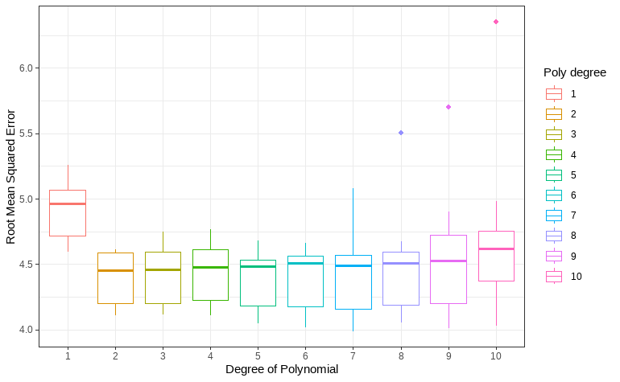

```r
g = ggplot(dl) +
      geom_boxplot(aes(poly_deg, rmse, color=factor(poly_deg))) +
      labs(y="Root Mean Squared Error") +
      scale_x_discrete(limits=factor(1:10), name="Degree of Polynomial") +
      guides(color = guide_legend("Poly degree")) +
      theme_bw()
g
```

# Discussion

1. The estimated MSE of 10 different test sets has large variability!!!!
2. In the validation approach, only a subset of the observations— those that are included in the training set rather than in the validation set— are used to fit the model. Since statistical methods tend to perform worse when trained on fewer observations, this suggests that the validation set error rate may tend to overestimate the test error rate for the model fit on the entire data set.

This shows us why we need cross-validation of various kinds, covered in subsequent sections.

# tidy?

See Ch05 Lab Crossvalidation for a tidy version. It’s quite a bit simpler.

# References

1. ISLR (2013) Chapter 5 Section 1.1, page 176-178.
2. Hartman, B. (2026) Ch05 Lab Crossvalidation. Accessible in Canvas at [Ch05 Lab Crossvalidation.nb.html](https://learn.stfrancis.edu/courses/1198828/files/66330137?wrap=1)